# Risk Factor Analysis

## Outcome Variable

**Outcome Variable:** pers_wast

## Predictor Variables

**Intervention Variable:** impsan

**Adjustment Set:**

unadjusted

## Stratifying Variables

The analysis was stratified on these variable(s):

- agecat
- studyid
- country

## Data Summary

| agecat | studyid | country | impsan | pers_wast | n_cell | n |
| --- | --- | --- | --- | --- | --- | --- |
| 0-24 months | ki0047075b-MAL-ED | BANGLADESH | 0 | 0 | 37 | 242 |
| 0-24 months | ki0047075b-MAL-ED | BANGLADESH | 0 | 1 | 1 | 242 |
| 0-24 months | ki0047075b-MAL-ED | BANGLADESH | 1 | 0 | 192 | 242 |
| 0-24 months | ki0047075b-MAL-ED | BANGLADESH | 1 | 1 | 12 | 242 |
| 0-24 months | ki0047075b-MAL-ED | BRAZIL | 0 | 0 | 4 | 210 |
| 0-24 months | ki0047075b-MAL-ED | BRAZIL | 0 | 1 | 0 | 210 |
| 0-24 months | ki0047075b-MAL-ED | BRAZIL | 1 | 0 | 204 | 210 |
| 0-24 months | ki0047075b-MAL-ED | BRAZIL | 1 | 1 | 2 | 210 |
| 0-24 months | ki0047075b-MAL-ED | INDIA | 0 | 0 | 113 | 233 |
| 0-24 months | ki0047075b-MAL-ED | INDIA | 0 | 1 | 12 | 233 |
| 0-24 months | ki0047075b-MAL-ED | INDIA | 1 | 0 | 100 | 233 |
| 0-24 months | ki0047075b-MAL-ED | INDIA | 1 | 1 | 8 | 233 |
| 0-24 months | ki0047075b-MAL-ED | NEPAL | 0 | 0 | 1 | 236 |
| 0-24 months | ki0047075b-MAL-ED | NEPAL | 0 | 1 | 0 | 236 |
| 0-24 months | ki0047075b-MAL-ED | NEPAL | 1 | 0 | 232 | 236 |
| 0-24 months | ki0047075b-MAL-ED | NEPAL | 1 | 1 | 3 | 236 |
| 0-24 months | ki0047075b-MAL-ED | PERU | 0 | 0 | 197 | 263 |
| 0-24 months | ki0047075b-MAL-ED | PERU | 0 | 1 | 1 | 263 |
| 0-24 months | ki0047075b-MAL-ED | PERU | 1 | 0 | 65 | 263 |
| 0-24 months | ki0047075b-MAL-ED | PERU | 1 | 1 | 0 | 263 |
| 0-24 months | ki0047075b-MAL-ED | SOUTH AFRICA | 0 | 0 | 244 | 250 |
| 0-24 months | ki0047075b-MAL-ED | SOUTH AFRICA | 0 | 1 | 2 | 250 |
| 0-24 months | ki0047075b-MAL-ED | SOUTH AFRICA | 1 | 0 | 4 | 250 |
| 0-24 months | ki0047075b-MAL-ED | SOUTH AFRICA | 1 | 1 | 0 | 250 |
| 0-24 months | ki0047075b-MAL-ED | TANZANIA, UNITED REPUBLIC OF | 0 | 0 | 241 | 241 |
| 0-24 months | ki0047075b-MAL-ED | TANZANIA, UNITED REPUBLIC OF | 0 | 1 | 0 | 241 |
| 0-24 months | ki0047075b-MAL-ED | TANZANIA, UNITED REPUBLIC OF | 1 | 0 | 0 | 241 |
| 0-24 months | ki0047075b-MAL-ED | TANZANIA, UNITED REPUBLIC OF | 1 | 1 | 0 | 241 |
| 0-24 months | ki1017093-NIH-Birth | BANGLADESH | 0 | 0 | 294 | 534 |
| 0-24 months | ki1017093-NIH-Birth | BANGLADESH | 0 | 1 | 33 | 534 |

[output cut: 134 more lines]

The following strata were considered:

- agecat: 0-24 months, studyid: ki0047075b-MAL-ED, country: BANGLADESH
- agecat: 0-24 months, studyid: ki0047075b-MAL-ED, country: BRAZIL
- agecat: 0-24 months, studyid: ki0047075b-MAL-ED, country: INDIA
- agecat: 0-24 months, studyid: ki0047075b-MAL-ED, country: NEPAL
- agecat: 0-24 months, studyid: ki0047075b-MAL-ED, country: PERU
- agecat: 0-24 months, studyid: ki0047075b-MAL-ED, country: SOUTH AFRICA
- agecat: 0-24 months, studyid: ki0047075b-MAL-ED, country: TANZANIA, UNITED REPUBLIC OF
- agecat: 0-24 months, studyid: ki1017093-NIH-Birth, country: BANGLADESH
- agecat: 0-24 months, studyid: ki1017093b-PROVIDE, country: BANGLADESH
- agecat: 0-24 months, studyid: ki1017093c-NIH-Crypto, country: BANGLADESH
- agecat: 0-24 months, studyid: ki1114097-CONTENT, country: PERU
- agecat: 0-24 months, studyid: ki1135781-COHORTS, country: GUATEMALA
- agecat: 0-24 months, studyid: ki1135781-COHORTS, country: INDIA
- agecat: 0-24 months, studyid: ki1135781-COHORTS, country: PHILIPPINES
- agecat: 0-24 months, studyid: ki1148112-LCNI-5, country: MALAWI
- agecat: 0-24 months, studyid: kiGH5241-JiVitA-3, country: BANGLADESH
- agecat: 0-24 months, studyid: kiGH5241-JiVitA-4, country: BANGLADESH
- agecat: 0-6 months, studyid: ki0047075b-MAL-ED, country: BANGLADESH
- agecat: 0-6 months, studyid: ki0047075b-MAL-ED, country: BRAZIL
- agecat: 0-6 months, studyid: ki0047075b-MAL-ED, country: INDIA
- agecat: 0-6 months, studyid: ki0047075b-MAL-ED, country: NEPAL
- agecat: 0-6 months, studyid: ki0047075b-MAL-ED, country: PERU
- agecat: 0-6 months, studyid: ki0047075b-MAL-ED, country: SOUTH AFRICA
- agecat: 0-6 months, studyid: ki0047075b-MAL-ED, country: TANZANIA, UNITED REPUBLIC OF
- agecat: 0-6 months, studyid: ki1017093b-PROVIDE, country: BANGLADESH
- agecat: 0-6 months, studyid: ki1114097-CONTENT, country: PERU
- agecat: 6-24 months, studyid: ki0047075b-MAL-ED, country: BANGLADESH
- agecat: 6-24 months, studyid: ki0047075b-MAL-ED, country: BRAZIL
- agecat: 6-24 months, studyid: ki0047075b-MAL-ED, country: INDIA
- agecat: 6-24 months, studyid: ki0047075b-MAL-ED, country: NEPAL
- agecat: 6-24 months, studyid: ki0047075b-MAL-ED, country: PERU
- agecat: 6-24 months, studyid: ki0047075b-MAL-ED, country: SOUTH AFRICA
- agecat: 6-24 months, studyid: ki0047075b-MAL-ED, country: TANZANIA, UNITED REPUBLIC OF
- agecat: 6-24 months, studyid: ki1017093-NIH-Birth, country: BANGLADESH
- agecat: 6-24 months, studyid: ki1017093b-PROVIDE, country: BANGLADESH
- agecat: 6-24 months, studyid: ki1017093c-NIH-Crypto, country: BANGLADESH
- agecat: 6-24 months, studyid: ki1114097-CONTENT, country: PERU
- agecat: 6-24 months, studyid: ki1135781-COHORTS, country: GUATEMALA
- agecat: 6-24 months, studyid: ki1135781-COHORTS, country: PHILIPPINES
- agecat: 6-24 months, studyid: ki1148112-LCNI-5, country: MALAWI
- agecat: 6-24 months, studyid: kiGH5241-JiVitA-4, country: BANGLADESH

### Dropped Strata

Some strata were dropped due to rare outcomes:

- agecat: 0-24 months, studyid: ki0047075b-MAL-ED, country: BANGLADESH
- agecat: 0-24 months, studyid: ki0047075b-MAL-ED, country: BRAZIL
- agecat: 0-24 months, studyid: ki0047075b-MAL-ED, country: NEPAL
- agecat: 0-24 months, studyid: ki0047075b-MAL-ED, country: PERU
- agecat: 0-24 months, studyid: ki0047075b-MAL-ED, country: SOUTH AFRICA
- agecat: 0-24 months, studyid: ki0047075b-MAL-ED, country: TANZANIA, UNITED REPUBLIC OF
- agecat: 0-24 months, studyid: ki1017093b-PROVIDE, country: BANGLADESH
- agecat: 0-24 months, studyid: ki1114097-CONTENT, country: PERU
- agecat: 0-24 months, studyid: ki1135781-COHORTS, country: GUATEMALA
- agecat: 0-24 months, studyid: ki1135781-COHORTS, country: PHILIPPINES
- agecat: 0-24 months, studyid: ki1148112-LCNI-5, country: MALAWI
- agecat: 0-6 months, studyid: ki0047075b-MAL-ED, country: BANGLADESH
- agecat: 0-6 months, studyid: ki0047075b-MAL-ED, country: BRAZIL
- agecat: 0-6 months, studyid: ki0047075b-MAL-ED, country: NEPAL
- agecat: 0-6 months, studyid: ki0047075b-MAL-ED, country: PERU
- agecat: 0-6 months, studyid: ki0047075b-MAL-ED, country: SOUTH AFRICA
- agecat: 0-6 months, studyid: ki0047075b-MAL-ED, country: TANZANIA, UNITED REPUBLIC OF
- agecat: 0-6 months, studyid: ki1017093b-PROVIDE, country: BANGLADESH
- agecat: 0-6 months, studyid: ki1114097-CONTENT, country: PERU
- agecat: 6-24 months, studyid: ki0047075b-MAL-ED, country: BANGLADESH
- agecat: 6-24 months, studyid: ki0047075b-MAL-ED, country: BRAZIL
- agecat: 6-24 months, studyid: ki0047075b-MAL-ED, country: NEPAL
- agecat: 6-24 months, studyid: ki0047075b-MAL-ED, country: PERU
- agecat: 6-24 months, studyid: ki0047075b-MAL-ED, country: SOUTH AFRICA
- agecat: 6-24 months, studyid: ki0047075b-MAL-ED, country: TANZANIA, UNITED REPUBLIC OF
- agecat: 6-24 months, studyid: ki1017093b-PROVIDE, country: BANGLADESH
- agecat: 6-24 months, studyid: ki1017093c-NIH-Crypto, country: BANGLADESH
- agecat: 6-24 months, studyid: ki1114097-CONTENT, country: PERU
- agecat: 6-24 months, studyid: ki1135781-COHORTS, country: GUATEMALA
- agecat: 6-24 months, studyid: ki1148112-LCNI-5, country: MALAWI

## Methods Detail

We’re interested in the causal parameters $E[Y_a]$ for all values of $a \in \mathcal{A}$. These parameters represent the mean outcome if, possibly contrary to fact, we intervened to set all units to have $A=a$. Under the randomization and positivity assumptions, these are identified by the statistical parameters $\psi_a=E_W[E_{Y|A,W}(Y|A=a,W)]$. In addition, we’re interested in the mean of $Y$, $E[Y]$ under no intervention (the observed mean). We will estimate these parameters by using SuperLearner to fit the relevant likelihood factors – $E_{Y|A,W}(Y|A=a,W)$ and $p(A=a|W)$, and then updating our likelihood fit using a joint TMLE.

For unadjusted analyses ($W=\{\}$), initial likelihoods were estimated using Lrnr_glm to estimate the simple $E(Y|A)$ and Lrnr_mean to estimate $p(A)$. For adjusted analyses, a small library containing Lrnr_glmnet, Lrnr_xgboost, and Lrnr_mean was used.

Having estimated these parameters, we will then use the delta method to estimate relative risks and attributable risks relative to a prespecified baseline level of $A$.

# Results Detail

## Results Plots

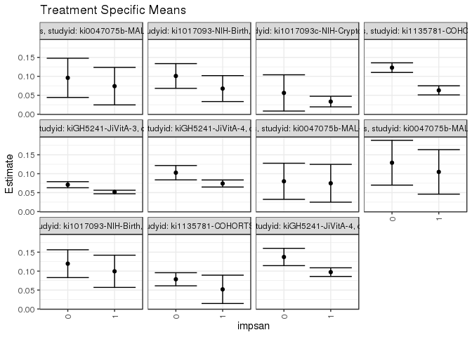

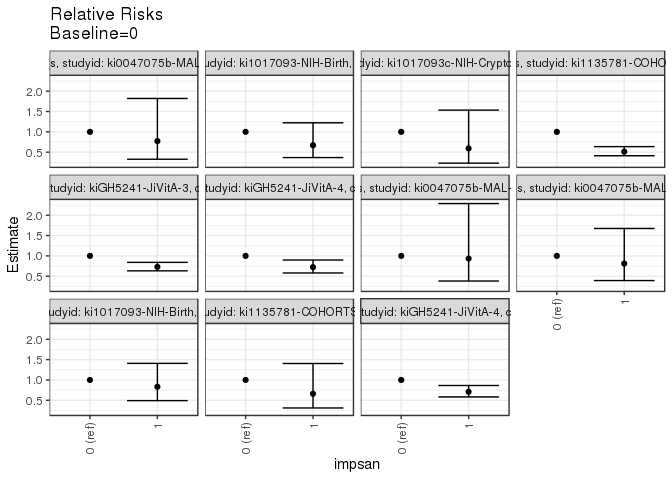

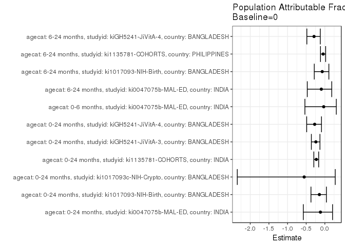

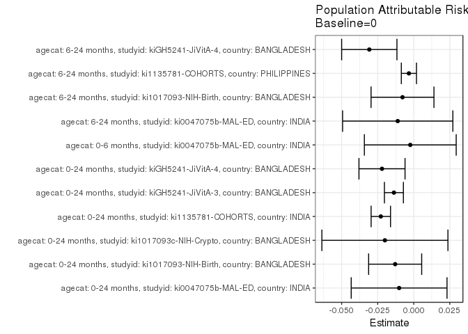

## Results Table

### Parameter: TSM

| agecat | studyid | country | intervention_level | baseline_level | estimate | ci_lower | ci_upper |
| --- | --- | --- | --- | --- | --- | --- | --- |
| 0-24 months | ki0047075b-MAL-ED | INDIA | 0 | NA | 0.0960000 | 0.0442456 | 0.1477544 |
| 0-24 months | ki0047075b-MAL-ED | INDIA | 1 | NA | 0.0740741 | 0.0245756 | 0.1235725 |
| 0-24 months | ki1017093-NIH-Birth | BANGLADESH | 0 | NA | 0.1009174 | 0.0682388 | 0.1335961 |
| 0-24 months | ki1017093-NIH-Birth | BANGLADESH | 1 | NA | 0.0676329 | 0.0333922 | 0.1018735 |
| 0-24 months | ki1017093c-NIH-Crypto | BANGLADESH | 0 | NA | 0.0561798 | 0.0083069 | 0.1040527 |
| 0-24 months | ki1017093c-NIH-Crypto | BANGLADESH | 1 | NA | 0.0333333 | 0.0193066 | 0.0473601 |
| 0-24 months | ki1135781-COHORTS | INDIA | 0 | NA | 0.1229444 | 0.1102077 | 0.1356811 |
| 0-24 months | ki1135781-COHORTS | INDIA | 1 | NA | 0.0629771 | 0.0509672 | 0.0749870 |
| 0-24 months | kiGH5241-JiVitA-3 | BANGLADESH | 0 | NA | 0.0709459 | 0.0628908 | 0.0790011 |
| 0-24 months | kiGH5241-JiVitA-3 | BANGLADESH | 1 | NA | 0.0517364 | 0.0470801 | 0.0563927 |
| 0-24 months | kiGH5241-JiVitA-4 | BANGLADESH | 0 | NA | 0.1027341 | 0.0838336 | 0.1216345 |
| 0-24 months | kiGH5241-JiVitA-4 | BANGLADESH | 1 | NA | 0.0741650 | 0.0648435 | 0.0834866 |
| 0-6 months | ki0047075b-MAL-ED | INDIA | 0 | NA | 0.0800000 | 0.0323382 | 0.1276618 |
| 0-6 months | ki0047075b-MAL-ED | INDIA | 1 | NA | 0.0747664 | 0.0248235 | 0.1247092 |
| 6-24 months | ki0047075b-MAL-ED | INDIA | 0 | NA | 0.1290323 | 0.0698982 | 0.1881663 |
| 6-24 months | ki0047075b-MAL-ED | INDIA | 1 | NA | 0.1047619 | 0.0460570 | 0.1634669 |
| 6-24 months | ki1017093-NIH-Birth | BANGLADESH | 0 | NA | 0.1196013 | 0.0829057 | 0.1562970 |
| 6-24 months | ki1017093-NIH-Birth | BANGLADESH | 1 | NA | 0.0994764 | 0.0569870 | 0.1419659 |
| 6-24 months | ki1135781-COHORTS | PHILIPPINES | 0 | NA | 0.0784946 | 0.0612013 | 0.0957880 |
| 6-24 months | ki1135781-COHORTS | PHILIPPINES | 1 | NA | 0.0518519 | 0.0144317 | 0.0892720 |
| 6-24 months | kiGH5241-JiVitA-4 | BANGLADESH | 0 | NA | 0.1372719 | 0.1144013 | 0.1601425 |
| 6-24 months | kiGH5241-JiVitA-4 | BANGLADESH | 1 | NA | 0.0973361 | 0.0859630 | 0.1087091 |

### Parameter: E(Y)

| agecat | studyid | country | intervention_level | baseline_level | estimate | ci_lower | ci_upper |
| --- | --- | --- | --- | --- | --- | --- | --- |
| 0-24 months | ki0047075b-MAL-ED | INDIA | NA | NA | 0.0858369 | 0.0497913 | 0.1218826 |
| 0-24 months | ki1017093-NIH-Birth | BANGLADESH | NA | NA | 0.0880150 | 0.0639627 | 0.1120673 |
| 0-24 months | ki1017093c-NIH-Crypto | BANGLADESH | NA | NA | 0.0361613 | 0.0225058 | 0.0498169 |
| 0-24 months | ki1135781-COHORTS | INDIA | NA | NA | 0.1000969 | 0.0909380 | 0.1092559 |
| 0-24 months | kiGH5241-JiVitA-3 | BANGLADESH | NA | NA | 0.0571793 | 0.0530871 | 0.0612716 |
| 0-24 months | kiGH5241-JiVitA-4 | BANGLADESH | NA | NA | 0.0806971 | 0.0720842 | 0.0893100 |
| 0-6 months | ki0047075b-MAL-ED | INDIA | NA | NA | 0.0775862 | 0.0430879 | 0.1120845 |
| 6-24 months | ki0047075b-MAL-ED | INDIA | NA | NA | 0.1179039 | 0.0760436 | 0.1597643 |
| 6-24 months | ki1017093-NIH-Birth | BANGLADESH | NA | NA | 0.1117886 | 0.0839169 | 0.1396604 |
| 6-24 months | ki1135781-COHORTS | PHILIPPINES | NA | NA | 0.0751174 | 0.0592797 | 0.0909550 |
| 6-24 months | kiGH5241-JiVitA-4 | BANGLADESH | NA | NA | 0.1064293 | 0.0958239 | 0.1170346 |

### Parameter: RR

| agecat | studyid | country | intervention_level | baseline_level | estimate | ci_lower | ci_upper |
| --- | --- | --- | --- | --- | --- | --- | --- |
| 0-24 months | ki0047075b-MAL-ED | INDIA | 0 | 0 | 1.0000000 | 1.0000000 | 1.0000000 |
| 0-24 months | ki0047075b-MAL-ED | INDIA | 1 | 0 | 0.7716049 | 0.3269765 | 1.8208469 |
| 0-24 months | ki1017093-NIH-Birth | BANGLADESH | 0 | 0 | 1.0000000 | 1.0000000 | 1.0000000 |
| 0-24 months | ki1017093-NIH-Birth | BANGLADESH | 1 | 0 | 0.6701801 | 0.3674449 | 1.2223367 |
| 0-24 months | ki1017093c-NIH-Crypto | BANGLADESH | 0 | 0 | 1.0000000 | 1.0000000 | 1.0000000 |
| 0-24 months | ki1017093c-NIH-Crypto | BANGLADESH | 1 | 0 | 0.5933333 | 0.2293801 | 1.5347647 |
| 0-24 months | ki1135781-COHORTS | INDIA | 0 | 0 | 1.0000000 | 1.0000000 | 1.0000000 |
| 0-24 months | ki1135781-COHORTS | INDIA | 1 | 0 | 0.5122405 | 0.4123071 | 0.6363954 |
| 0-24 months | kiGH5241-JiVitA-3 | BANGLADESH | 0 | 0 | 1.0000000 | 1.0000000 | 1.0000000 |
| 0-24 months | kiGH5241-JiVitA-3 | BANGLADESH | 1 | 0 | 0.7292372 | 0.6322494 | 0.8411030 |
| 0-24 months | kiGH5241-JiVitA-4 | BANGLADESH | 0 | 0 | 1.0000000 | 1.0000000 | 1.0000000 |
| 0-24 months | kiGH5241-JiVitA-4 | BANGLADESH | 1 | 0 | 0.7219128 | 0.5803161 | 0.8980591 |
| 0-6 months | ki0047075b-MAL-ED | INDIA | 0 | 0 | 1.0000000 | 1.0000000 | 1.0000000 |
| 0-6 months | ki0047075b-MAL-ED | INDIA | 1 | 0 | 0.9345794 | 0.3818500 | 2.2873873 |
| 6-24 months | ki0047075b-MAL-ED | INDIA | 0 | 0 | 1.0000000 | 1.0000000 | 1.0000000 |
| 6-24 months | ki0047075b-MAL-ED | INDIA | 1 | 0 | 0.8119048 | 0.3936563 | 1.6745302 |
| 6-24 months | ki1017093-NIH-Birth | BANGLADESH | 0 | 0 | 1.0000000 | 1.0000000 | 1.0000000 |
| 6-24 months | ki1017093-NIH-Birth | BANGLADESH | 1 | 0 | 0.8317336 | 0.4915711 | 1.4072853 |
| 6-24 months | ki1135781-COHORTS | PHILIPPINES | 0 | 0 | 1.0000000 | 1.0000000 | 1.0000000 |
| 6-24 months | ki1135781-COHORTS | PHILIPPINES | 1 | 0 | 0.6605784 | 0.3106174 | 1.4048271 |
| 6-24 months | kiGH5241-JiVitA-4 | BANGLADESH | 0 | 0 | 1.0000000 | 1.0000000 | 1.0000000 |
| 6-24 months | kiGH5241-JiVitA-4 | BANGLADESH | 1 | 0 | 0.7090748 | 0.5823859 | 0.8633228 |

### Parameter: PAR

| agecat | studyid | country | intervention_level | baseline_level | estimate | ci_lower | ci_upper |
| --- | --- | --- | --- | --- | --- | --- | --- |
| 0-24 months | ki0047075b-MAL-ED | INDIA | 0 | NA | -0.0101631 | -0.0433875 | 0.0230613 |
| 0-24 months | ki1017093-NIH-Birth | BANGLADESH | 0 | NA | -0.0129024 | -0.0313018 | 0.0054969 |
| 0-24 months | ki1017093c-NIH-Crypto | BANGLADESH | 0 | NA | -0.0200184 | -0.0637325 | 0.0236956 |
| 0-24 months | ki1135781-COHORTS | INDIA | 0 | NA | -0.0228475 | -0.0295762 | -0.0161187 |
| 0-24 months | kiGH5241-JiVitA-3 | BANGLADESH | 0 | NA | -0.0137666 | -0.0203501 | -0.0071831 |
| 0-24 months | kiGH5241-JiVitA-4 | BANGLADESH | 0 | NA | -0.0220369 | -0.0380216 | -0.0060523 |
| 0-6 months | ki0047075b-MAL-ED | INDIA | 0 | NA | -0.0024138 | -0.0342553 | 0.0294277 |
| 6-24 months | ki0047075b-MAL-ED | INDIA | 0 | NA | -0.0111283 | -0.0493665 | 0.0271098 |
| 6-24 months | ki1017093-NIH-Birth | BANGLADESH | 0 | NA | -0.0078127 | -0.0296249 | 0.0139995 |
| 6-24 months | ki1135781-COHORTS | PHILIPPINES | 0 | NA | -0.0033773 | -0.0086298 | 0.0018753 |
| 6-24 months | kiGH5241-JiVitA-4 | BANGLADESH | 0 | NA | -0.0308427 | -0.0500215 | -0.0116638 |

### Parameter: PAF

| agecat | studyid | country | intervention_level | baseline_level | estimate | ci_lower | ci_upper |
| --- | --- | --- | --- | --- | --- | --- | --- |
| 0-24 months | ki0047075b-MAL-ED | INDIA | 0 | NA | -0.1184000 | -0.5773145 | 0.2069948 |
| 0-24 months | ki1017093-NIH-Birth | BANGLADESH | 0 | NA | -0.1465938 | -0.3723039 | 0.0419926 |
| 0-24 months | ki1017093c-NIH-Crypto | BANGLADESH | 0 | NA | -0.5535869 | -2.3478844 | 0.2790575 |
| 0-24 months | ki1135781-COHORTS | INDIA | 0 | NA | -0.2282533 | -0.2948157 | -0.1651126 |
| 0-24 months | kiGH5241-JiVitA-3 | BANGLADESH | 0 | NA | -0.2407622 | -0.3611422 | -0.1310287 |
| 0-24 months | kiGH5241-JiVitA-4 | BANGLADESH | 0 | NA | -0.2730823 | -0.4865035 | -0.0903025 |
| 0-6 months | ki0047075b-MAL-ED | INDIA | 0 | NA | -0.0311111 | -0.5349058 | 0.3073255 |
| 6-24 months | ki0047075b-MAL-ED | INDIA | 0 | NA | -0.0943847 | -0.4702271 | 0.1853790 |
| 6-24 months | ki1017093-NIH-Birth | BANGLADESH | 0 | NA | -0.0698882 | -0.2832505 | 0.1079989 |
| 6-24 months | ki1135781-COHORTS | PHILIPPINES | 0 | NA | -0.0449597 | -0.1167039 | 0.0221752 |
| 6-24 months | kiGH5241-JiVitA-4 | BANGLADESH | 0 | NA | -0.2897949 | -0.4823613 | -0.1222438 |